# Climate Report

Temperature and Precipitation 1960-2014

Steven Lu

9 May 2019

### Data

This data is from the University of Delaware air temps and precipitation collection. The members collected a large amount of data from weather stations from Global Historical Climate Networks (GHCN2) as well as archives from Legates and Willmott. The data we used spanned from 3 different years (1960, 1986, 2014) in order to form these maps. The maps are used in order to see the ongoing trends or potential changes that each of the specified years had. This dataset can be used in conjunction with International Comprehensive Ocean-Atmosphere Data Set (ICOADS) to create a full map of the world.

## 1960 April Air-temperature

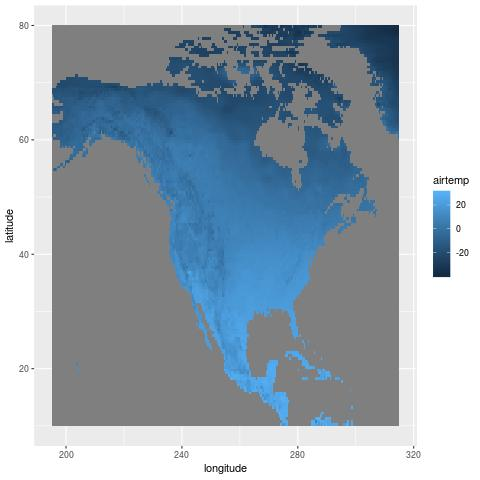

1960 Air Temps

## 1986 April Air-temperature

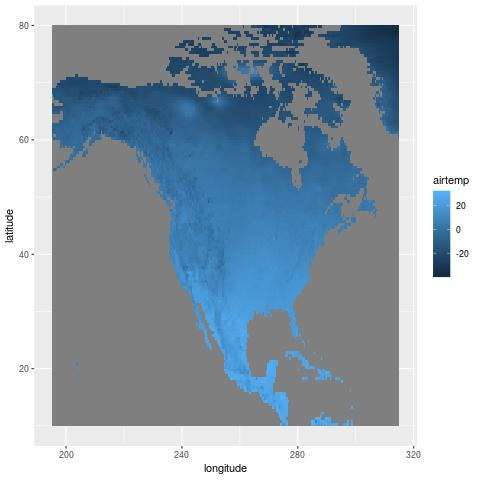

1986 Air Temps

## 2014 April Air-temperature

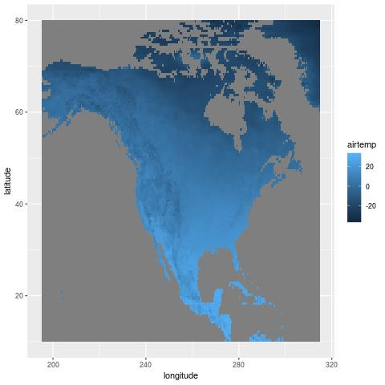

2014 Air Temps

The current temperature patterns look realistic and are somewhat reminiscent of the past. There seems to be an ebb and flow to how the temperature changes over the years. It looks as if the temperatures in 1960s to 1986s changed as the map got brighter. This implies that there has been a shift in temperature (most likely and increase) as the colors changed from darker shades of blue to lighter shades of blue. However from 1986 to 2014 the temperatures seemed to go down as the colors reverted back to the dark shades beforehand. Some places remained relatively similar throughout the 3 images such as Southern California as it is hot year round especially during April as it is the middle of spring and transition to summer.

## 1960 April Precipitation

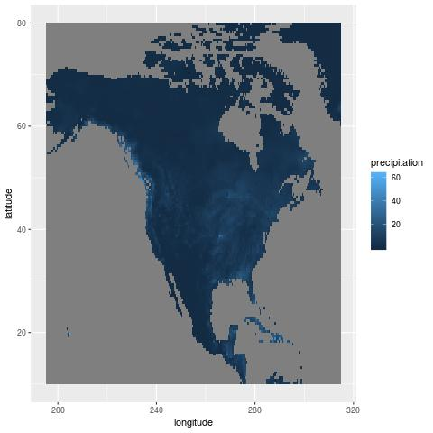

1960 Precipitation

## 1986 April Precipitation

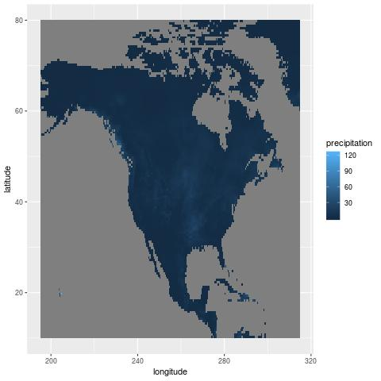

1986 Precipitation

## 2014 April Precipitation

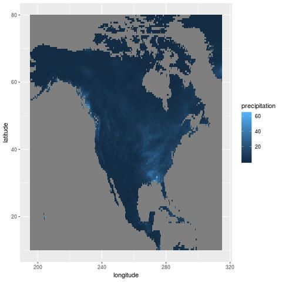

2014 Precipitation

The scales in the 1986 and 2014 versions are different which I found interesting as the peak amount of rain is higher during 1986 as a result. However, the scales between 2014 and 1960 are the same (60 for precipitation) which symbolizes the range of the data between that era. The most rain seems to be around the South eastern area (Florida, Mississippi, etc). This could be a result of the location as the closer you get to the equator the warmer the weather which causes a larger potential of rainfall. Canadian rainfall also increased throughout the years which seems interesting given the trends beforehand. Coastal cities also seemed to have a lot more rainfall than before as well. The results also do look reasonable and there seems to be major differences between years 1986 and 2014. The 1960s map and the 2014s map look the most alike and that must be due to the cyclical nature of the weather.